# Estudo

```r
library(tidyverse)
library(readxl)
```

# Comércio

## Participação nos fluxos de comércio

### Participação nas exportações

```r
exp_participacao <- comerciobr::sh1_df %>%
  filter(co_ano == max(co_ano)-1) %>%
  filter(path == "EXP") %>%
  group_by(no_pais) %>%
  summarise(value = sum(value)) %>%
  ungroup() %>%
  mutate(total = sum(value)) %>%
  mutate(porcentagem = value/total)
```

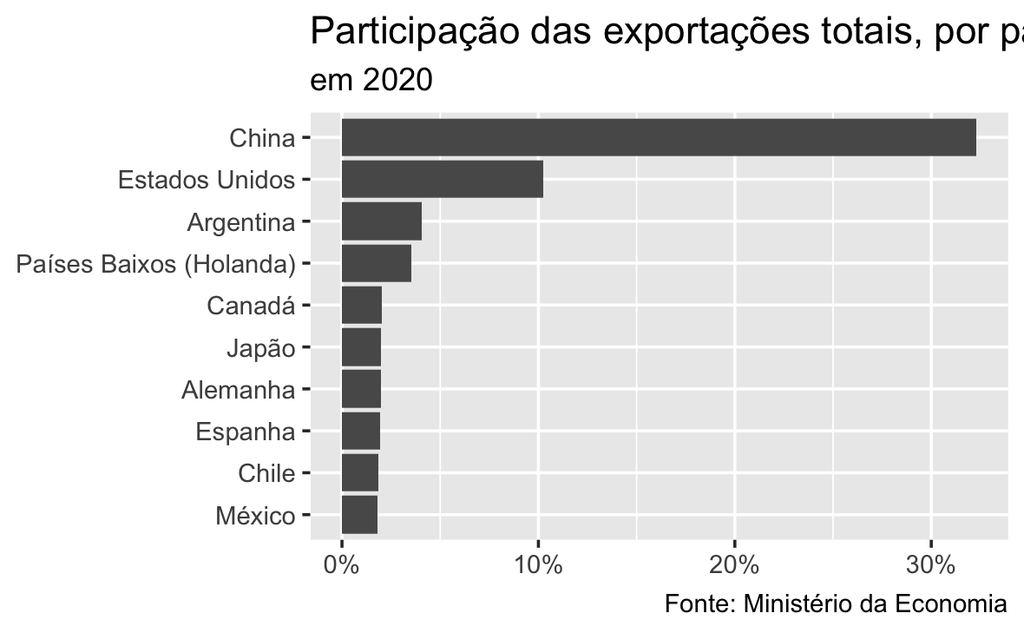

### Participação nas importações

```r
imp_participacao <- comerciobr::sh1_df %>%
  filter(co_ano == max(co_ano)-1) %>%
  filter(path == "IMP") %>%
  group_by(no_pais) %>%
  summarise(value = sum(value)) %>%
  ungroup() %>%
  mutate(total = sum(value)) %>%
  mutate(porcentagem = value/total)
```

```r
imp_participacao %>%
  slice_max(porcentagem, n = 10) %>%
  mutate(no_pais = fct_reorder(no_pais, porcentagem, sum)) %>%
  ggplot() +
  geom_col(aes(porcentagem, no_pais)) +
  scale_x_continuous(labels = scales::label_percent()) +
  labs(title = "Participação das exportações totais, por país",
       subtitle = "em 2020",
       caption = "Fonte: Ministério da Economia",
       x = NULL, y = NULL
       )
```

[output not shown]

### Participação na corrente de comércio

```r
corrente_participacao <- comerciobr::sh1_df %>%
  filter(co_ano == max(co_ano)-1) %>%
  group_by(path, no_pais) %>%
  summarise(value = sum(value)) %>%
  pivot_wider(names_from = path, values_from = value) %>%
  mutate(corrente = EXP + IMP,
         saldo = EXP - IMP) %>%
  select(no_pais, corrente) %>%
  drop_na() %>%
  mutate(total = sum(corrente)) %>%
  mutate(porcentagem = corrente/total)
```

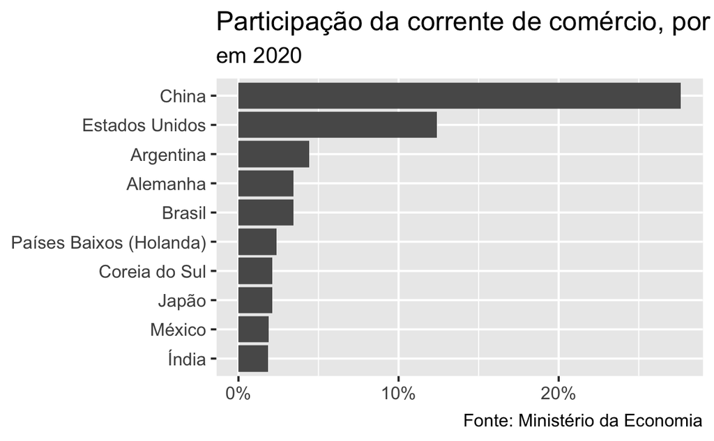

Estou na dúvida de como tratar os saldos comerciais, na medida em que eles podem ser negativos e positivos. Não acho que a melhor maneira de tratar esses dados, da perspectiva do índice, seja através da porcentagem. É preciso encontrar melhor maneira para lidar com esses dados.

## Comércio Intraindústria

# Tecnologia

## Depósitos de Patentes

```r
patentes <- read_excel("data/deposito_patentes_tipo_pi_por_pais.xls", skip = 7) %>%
  rename(País = 1) %>%
  select(-c(2)) %>%
  pivot_longer(cols = 2:last_col(), names_to = "ano", values_to = "patentes")
```

```
* `` -> ...1
* `` -> ...2
```

Os dados de patentes selecionados foram adquiridos no endereço eletrônico do [INPI, setor de estatísticas](https://www.gov.br/inpi/pt-br/central-de-conteudo/estatisticas), particularmente o setor de “Indicadores de Propriedade Intelectual”. Foi feito o download das tabelas completas do último ano disponível, 2019. Dentre os mais variados indicadores disponíveis, foi escolhido o seguinte indicador: **Depósito de patentes tipo Patentes de Invenção, por país de origem**. As tabelas indicam a quantidade dos pedidos de patentes de 2000 até o último ano disponível.

Para fins deste estudo, considerou-se que os dados de pedidos de patente relativos ao último ano disponível pode representar oscilação nos dados. Por isso, optou-se pela soma de todos os pedidos de patente, por país, desde o início da série temporal, no ano de 2000.

[output not shown]

[output cut: 147 more lines]

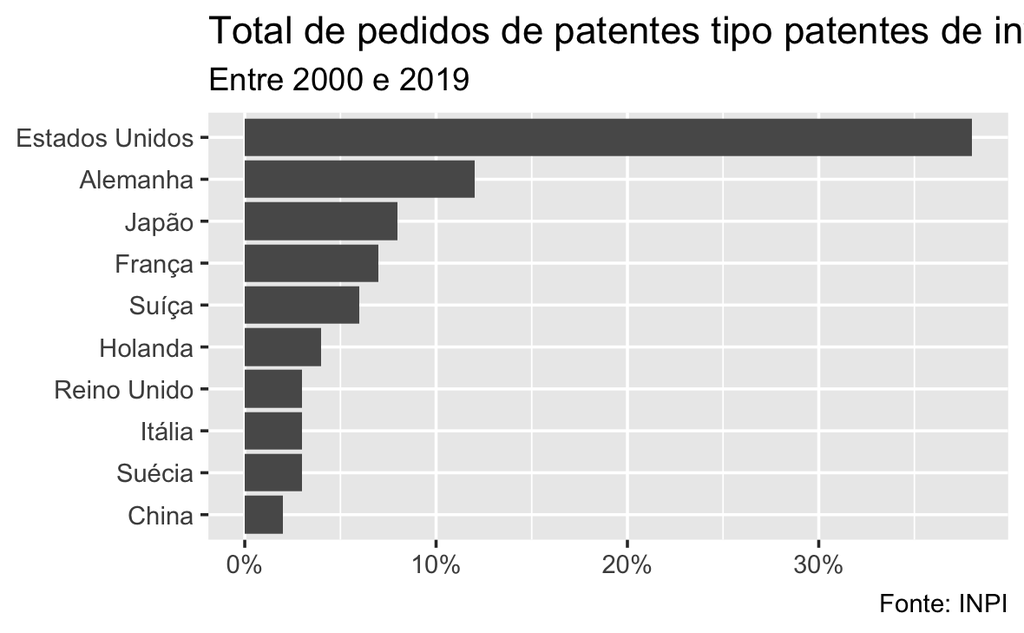

# Investimentos

## Banco Central

### Dados de estoque, Controlador Final

```r
controlador_final_investimentos <- investimentos::bc_idp_pais_controlador %>%
  filter(discriminacao != "Total") %>%
  filter(ano == max(ano)) %>%
  drop_na() %>%
  mutate(total = sum(value)) %>%
  mutate(porcentagem = value/total) %>%
  mutate(discriminacao = fct_reorder(discriminacao, porcentagem, sum))
```

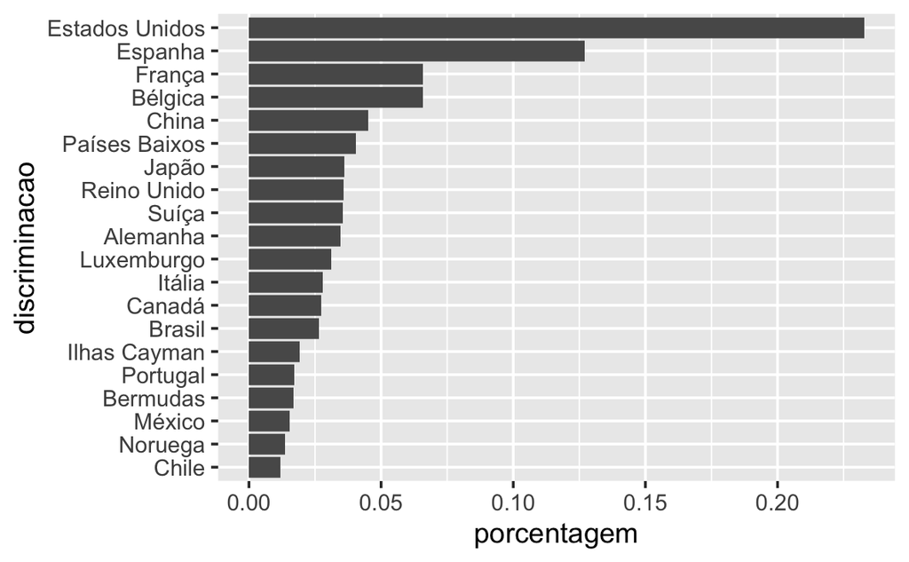

## Fluxos para o Brasil - comparação mundo-país

1. Porcentagem dos fluxos mundiais de investimento recebidos pelo Brasil, por ano.
2. Porcentagem dos fluxos de um determinado país de investimento recebido pelo Brasil, por ano
3. Calcular a diferença entre os dois.

### UNCTAD - fluxos mundiais de investimento recebidos pelo Brasil, por ano

```r
idp_brasil_pct_mundo$percentage_of_total_world
```

```
[1] 4.674993
```

### OCDE - fluxos de investimentos, por país

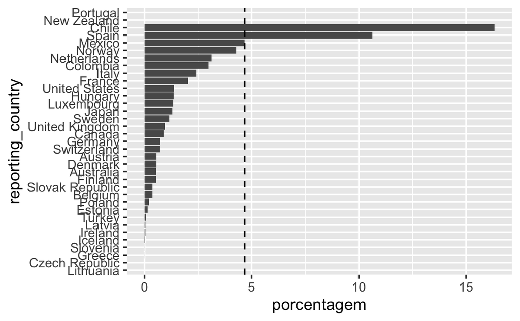

```r
ocde_investimentos_brasil %>%
  left_join(ocde_investimentos_total) %>%
  mutate(porcentagem = value/total_fdi) %>%
  arrange(desc(porcentagem)) %>%
  mutate(reporting_country = fct_reorder(reporting_country, porcentagem, sum)) %>%
  mutate(porcentagem = porcentagem*100) %>%
  ggplot() +
  geom_col(aes(porcentagem, reporting_country)) +
  geom_vline(xintercept = idp_brasil_pct_mundo$percentage_of_total_world, linetype = 2)
```

# Financiamento

Quadro 12 - Participação estrangeira no capital votante de instituições do SFN

https://www.bcb.gov.br/content/publicacoes/evolucaosfn/r202012/T4CE_Quadro%2012%20-%20Participa%C3%A7%C3%A3o%20estrangeira%20no%20capital%20votante%20de%20institui%C3%A7%C3%B5es%20do%20SFN.pdf

https://www.bcb.gov.br/publicacoes/relatorioevolucaosfnano

## Empréstimos diretos de longo prazo - passivos

- Dados em US$ Milhões

| Discriminação | 2010 | 2011 | 2012 | 2013 | 2014 | 2015 | 2016 | 2017 | 2018 | 2019 | 2020 |
| --- | --- | --- | --- | --- | --- | --- | --- | --- | --- | --- | --- |
| Estados Unidos | 3230.7985821299999 | 21842.45251608 | 12477.284350 | 11718.814919 | 15450.545807 | 23572.998960209999 | 15708.105700 | 11158.44950 | 13738.462782 | 14927.974648 | 11011.352374 |
| Ilhas Cayman | 1216.5010457000001 | 3314.80922633 | 5972.259416 | 4291.903025 | 4226.173371 | 7695.2753865799996 | 3141.195049 | 6665.17792 | 11326.669323 | 3896.250793 | 6647.230117 |
| Áustria | 1685.73210457 | 5119.6249550000002 | 4944.587101 | 6004.584109 | 5191.473252 | 1468.6586629400001 | 428.165852 | 1097.87326 | 1331.508829 | 1204.666317 | 1318.959614 |
| Luxemburgo | 417.27345173999998 | 290.68298016 | 178.625333 | 647.464954 | 1724.028796 | 3750.3159326800001 | 1342.271936 | 1165.03546 | 2044.576221 | 3097.827445 | 3095.616318 |
| Bahamas | 316.84140522000001 | 1966.7225534900001 | 970.628937 | 2244.059255 | 1416.729082 | 2696.4989366700001 | 645.892686 | 1251.84310 | 1348.769070 | 2020.592188 | 886.530309 |
| Países Baixos | 588.61283562999995 | 552.58754324999995 | 128.402106 | 292.470726 | 1135.357615 | 1371.44674108 | 1465.090823 | 1787.07575 | 1453.180861 | 888.505726 | 1070.079387 |
| França | 673.69469417000005 | 1625.2975160399999 | 295.764791 | 1030.971954 | 683.509552 | 2341.8284438699998 | 635.729425 | 1888.04018 | 1406.224111 | 1652.091196 | 2106.057652 |
| Reino Unido | 986.59646713999996 | 502.97672420999999 | 217.300454 | 308.330342 | 285.569525 | 450.13211257 | 587.280044 | 1072.49305 | 1296.879635 | 1300.109568 | 265.288287 |
| Japão | 958.52399680999997 | 836.35394158999998 | 358.825828 | 612.820993 | 1209.210489 | 224.63134092000001 | 158.305767 | 490.69085 | 124.083176 | 137.287250 | 22.055371 |
| Espanha | 25.772684290000001 | 15.44316841 | 365.014457 | 197.220769 | 396.201180 | 883.71099972000002 | 56.041985 | 361.28070 | 75.406251 | 945.455009 | 70.048896 |

[output cut: 11 more lines]

Empréstimos diretos de longo prazo passivos

https://www.bcb.gov.br/content/estatisticas/Documents/Tabelas_especiais/EmprestimosDiretosLongoPrazoPassivop.xls

## Endividamento em moeda estrangeira

Dívida externa - distribuição por moeda

https://www.bcb.gov.br/content/estatisticas/Documents/Tabelas_especiais/DivMoeda_T.xlsx